# Statistical inference with the GSS data

## Setup

### Load packages

```r
library(ggplot2)
library(dplyr)
library(statsr)
```

### Load data

```r
load("gss.Rdata")
```

## Part 1: Data

GSS data was obtained by face-to-fce interview (vast majority), computer-assisted personal interview (CAPI) (began 2002), or telephone. Source of bias: due to long interview, there are number of people who do not participate in the interviews or do not fully answer the questions.

Scope of inference-generalization: the data consists of 57061 people from American society with random sampling. Hence, this study has generalization.

Scope of inference-causation: this is an observational study and has no causation. Only correlation could be established using statistical inference.

## Part 2: Research question

** Question 1 **

Is there any difference between average year of school completed of the person interviewed and spouse compared to parents, finding 95% confident interval of difference in between education of young generation with their parents. This question is of particular interest, since it explains gender difference between different generation. Divide the education level in to high (larger than 10), and low (less or equal to 10), and perform inference. Is there a positive tendency or negative tendency accross generations?

Four parameters needed:

educ: Highest year of school completed

paeduc: Highest year of school completed, father

maeduc: Highest year of school completed, mother

speduc: Highest year of school completed, spouse

** Question 2 **

Is there any correlation between race of respondence and his/her political view for extreme group (Extremely Conservative and Extremely Liberal)? This question refers to the fact that people with different races could have different thinking of self as Extremely liberal or Extremely Conservative. This question is interesting because the races also affects political views.

Two parameters needed:

race: Race of respondent

polviews: Think of self as liberal or conservative

** Question 3 **

Study the difference between hours of watching TV per days for man and woman. This is important question concerning time spent in front of TV for man and woman.

Two parameters needed:

sex: Respondent’s sex

tvhours: hours of watching TV per days

## Part 3: Exploratory data analysis

EDA and summary statistics.

** Question 1 **

```r
load("gss.Rdata")
gss  <- gss %>%
        filter(!is.na(educ),!is.na(paeduc),!is.na(maeduc),!is.na(speduc)) %>%
        mutate(average_educ = (educ+speduc)/2, average_parenteduc = (maeduc+paeduc)/2, diff=educ+speduc-maeduc-paeduc)
str(gss$diff)
```

```
##  int [1:21385] 6 7 9 8 6 7 11 4 2 11 ...
```

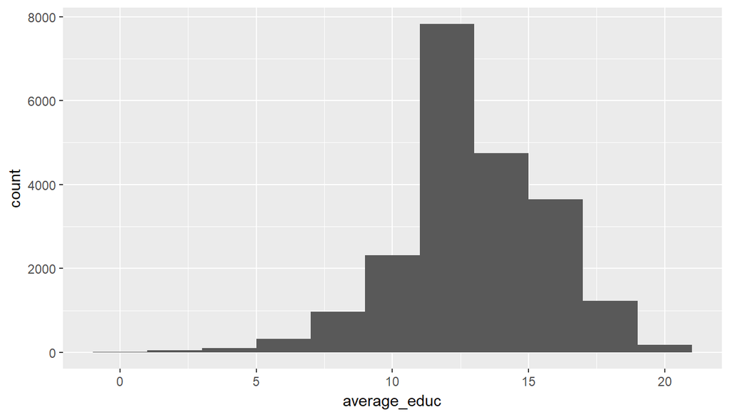

```r
ggplot(data = gss, mapping = aes(average_educ)) + geom_histogram(binwidth = 2)
```

```r
gss %>%
  summarise(av_mean = mean(average_educ), av_median = median(average_educ), av_sd = sd(average_educ),
  av_min = min(average_educ), av_max = max(average_educ))
```

```
##    av_mean av_median    av_sd av_min av_max
## 1 13.23477        13 2.739851      0     20
```

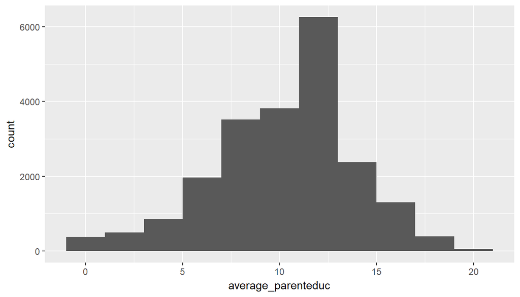

```r
ggplot(data = gss, mapping = aes(average_parenteduc)) + geom_histogram(binwidth = 2)
```

```r
gss %>%
  summarise(parents_mean = mean(average_parenteduc), parents_median = median(average_parenteduc), parents_sd = sd(average_parenteduc),
  parents_min = min(average_parenteduc), parents_max = max(average_parenteduc))
```

```
##   parents_mean parents_median parents_sd parents_min parents_max
## 1     10.51026             11   3.618359           0          20
```

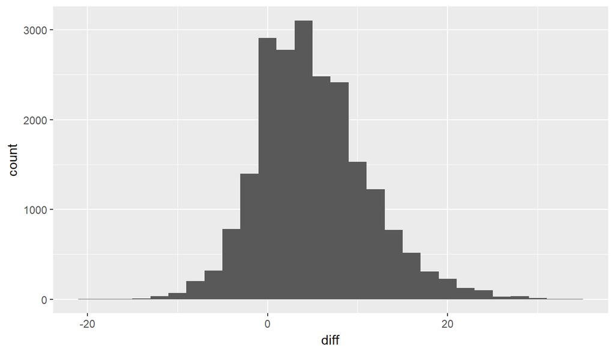

```r
ggplot(data = gss, mapping = aes(diff)) + geom_histogram(binwidth = 2)
```

```r
gss %>%
  summarise(diff_mean = mean(diff), diff_median = median(diff), diff_sd = sd(diff),
  diff_min = min(diff), diff_max = max(diff))
```

```
##   diff_mean diff_median  diff_sd diff_min diff_max
## 1  5.449006           5 6.127399      -20       35
```

** Question 2 **

```r
gss <- gss %>%
      group_by(polviews,race) %>%
       filter(!is.na(race),!is.na(polviews),polviews == "Extrmly Conservative"|polviews == "Extremely Liberal")

gss %>%
  group_by(polviews,race) %>%
  filter(!is.na(race),!is.na(polviews),polviews =="Extrmly Conservative" | polviews=="Extremely Liberal") %>%
  summarise(count = n())
```

```
## # A tibble: 6 x 3
## # Groups:   polviews [?]
##   polviews             race  count
##   <fct>                <fct> <int>
## 1 Extremely Liberal    White   248
## 2 Extremely Liberal    Black    49
## 3 Extremely Liberal    Other    11
## 4 Extrmly Conservative White   526
## 5 Extrmly Conservative Black    52
## 6 Extrmly Conservative Other    29
```

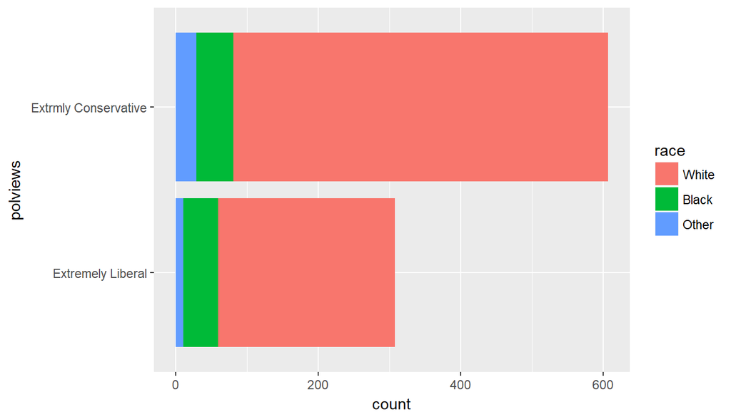

```r
ggplot(data = gss, mapping = aes(polviews, fill = race)) + coord_flip() + geom_bar(position="stack")
```

Figure shows bar plot of political view by races.

** Question 3 **

```r
load("gss.Rdata")
gss %>%
group_by(sex,tvhours) %>%
filter(!is.na(sex),!is.na(tvhours),tvhours != "") %>%
summarise(count = n())
```

```
## # A tibble: 47 x 3
## # Groups:   sex [?]
##    sex   tvhours count
##    <fct>   <int> <int>
##  1 Male        0   697
##  2 Male        1  3124
##  3 Male        2  4174
##  4 Male        3  2865
##  5 Male        4  1825
##  6 Male        5   839
##  7 Male        6   555
##  8 Male        7   120
##  9 Male        8   230
## 10 Male        9    18
## # ... with 37 more rows
```

EDA by genders and TV hours.

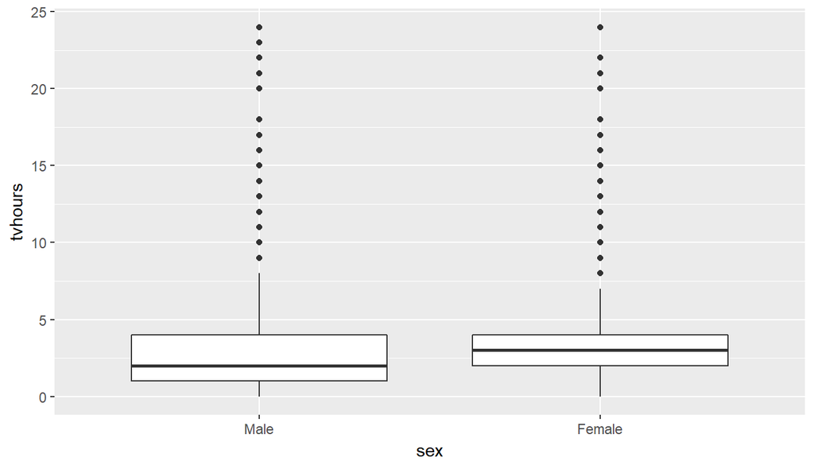

```r
ggplot(data = gss, mapping = aes(x = sex, y = tvhours)) + geom_boxplot()# +   facet_grid(sex ~.)
```

This is a box plot showing the gender difference in number of TV hours.

## Part 4: Inference

** Question 1 **

Confidence level- we would like to build confident interval of diff: point estimate +/- 1.96*SE

```r
conf_interval <- c(5.449006 - 1.96*6.127399/sqrt(21385),5.449006 + 1.96*6.127399/sqrt(21385))
str(conf_interval)
```

```
##  num [1:2] 5.37 5.53
```

```r
gss  <- gss %>%
        filter(!is.na(educ),!is.na(paeduc),!is.na(maeduc),!is.na(speduc)) %>%
        mutate(average_educ = (educ+speduc)/2, average_parenteduc = (maeduc+paeduc)/2, diff=educ+speduc-maeduc-paeduc)

gss <- gss %>%
  mutate(educ_level = ifelse(average_educ>10, "high", "low"), parents_level = ifelse(average_parenteduc>10, "high", "low"))
inference(y = educ_level, x = parents_level, data = gss, statistic = "proportion", type = "ht", alternative = "greater", method = "theoretical", success = "high")
```

```
## Response variable: categorical (2 levels, success: high)
## Explanatory variable: categorical (2 levels)
## n_high = 12089, p_hat_high = 0.9811
## n_low = 9296, p_hat_low = 0.769
## H0: p_high =  p_low
## HA: p_high > p_low
## z = 48.9063
## p_value = < 0.0001
```

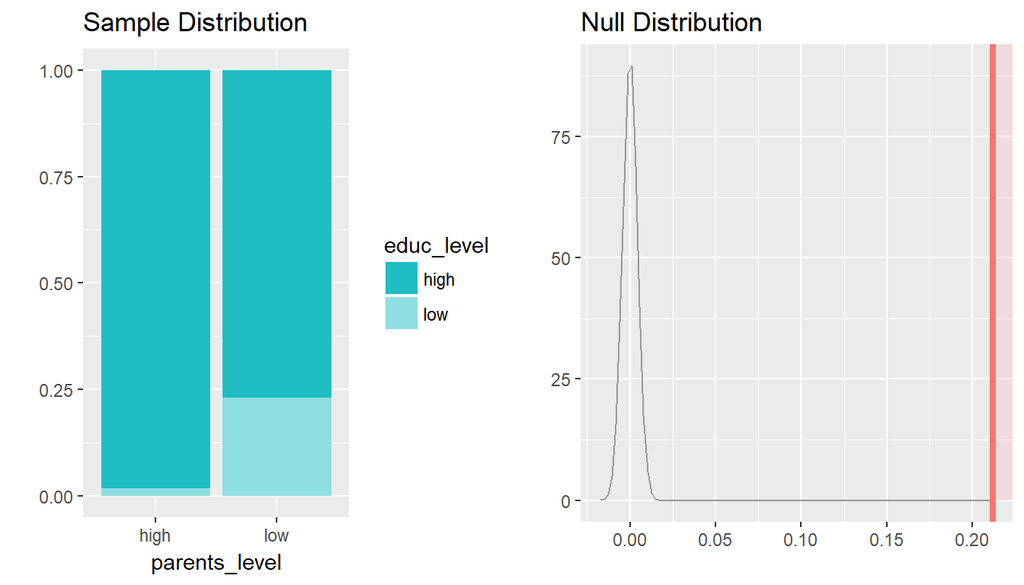

This is an inference study of education level in young generation (educ_level - response variable) and parents’ education level (parents_level - explanatory variable).

** Question 2 **

```r
load("gss.Rdata")
gss <- gss %>%
      group_by(polviews,race) %>%
       filter(!is.na(race),!is.na(polviews),polviews == "Extrmly Conservative"|polviews == "Extremely Liberal")

inference(y = polviews, x = race, data = gss, statistic = "proportion", type = "ht", alternative = "greater", method = "theoretical", success = "atheist")
```

```
## Response variable: categorical (7 levels)
## Explanatory variable: categorical (3 levels)
## Observed:
##        y
## x       Extremely Liberal Extrmly Conservative
##   White               933                 1196
##   Black               316                  238
##   Other                81                   72
##
## Expected:
##        y
## x       Extremely Liberal Extrmly Conservative
##   White         998.43794           1130.56206
##   Black         259.80959            294.19041
##   Other          71.75247             81.24753
##
## H0: race and polviews are independent
## HA: race and polviews are dependent
## chi_sq = 33.2058, df = 2, p_value = 0
```

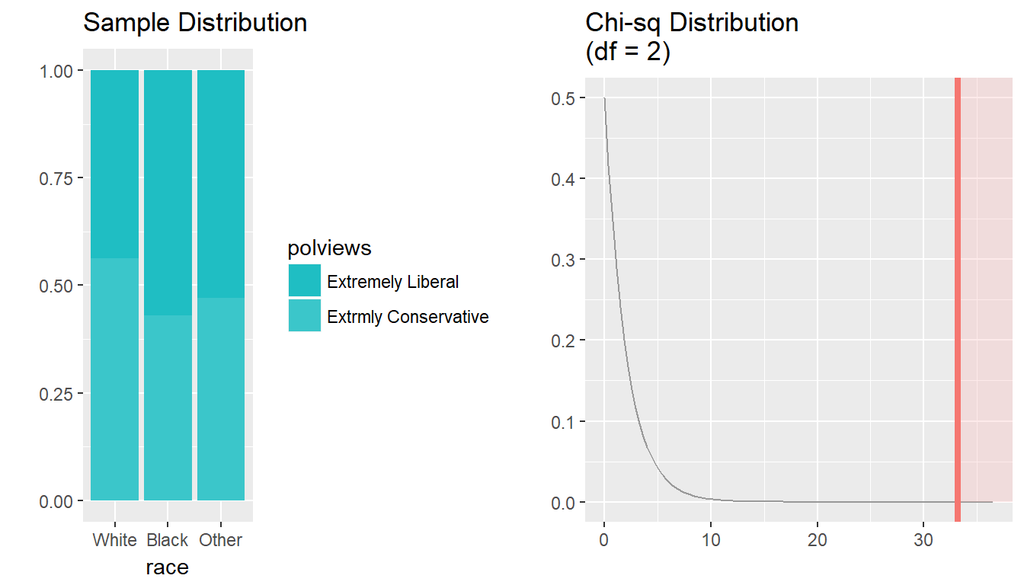

Null hypothesis: race and polviews are independent

Alternative hypothesis: race and polviews are dependent

Conclusion: using chi square method of inference, we conclude that race and political views are dependent.

** Question 3 **

```r
gss <- gss %>%
       filter(!is.na(tvhours))
inference(y = tvhours, x = sex, data = gss, statistic = "mean", type = "ci", conf_level = 0.95, method = "theoretical")
```

```
## Response variable: numerical, Explanatory variable: categorical (2 levels)
## n_Male = 921, y_bar_Male = 2.9142, s_Male = 2.4918
## n_Female = 968, y_bar_Female = 3.311, s_Female = 3.1379
## 95% CI (Male - Female): (-0.652 , -0.1415)
```

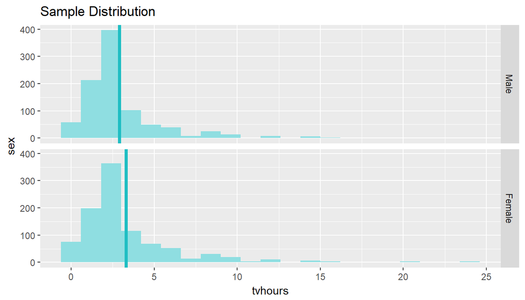

Figure shows the gender difference in TV hours. Conclusion from the inference: we are 95% confidence that the mean TVhours of male is smaller then the mean TVhous of female i.e the difference is between (-0.652, -0.1415)